# Modelos Regresión Logistica por selección de veariables para predecir el precio de viviendas

Minería de Datos y Modelización Predictiva

29/1/2020

## Introducción y esquema de trabajo

A lo largo de este documento se desarrolla el procedimiento básico para enfrentarse a un análisis de *Regresión Logística con selección de variables* cuando los datos de entrada se encuentran previamente depurados. Se puede esquematizar el proceso como sigue:

1. Construcción de modelos manuales (ver RL_viviendas)
2. Esquema de se lección de variables clásico bajo el esquema Training/Test
   - Efectos principales
   - Efectos principales + interacciones
   - Efectos principales + transformaciones
   - Efectos principales + transformaciones + interacciones
3. Esquema de comprobación de resultados por Validación Cruzada Repetida
   - Considerando los mejores modelos de entre los anteriores tratamos de evitar la influencia de la semilla de inicialización de las particiones.
4. Esquema de Selección aleatoria (muchos modelos por particiones aleatorias con reemplazamiento, repetidas)
5. Comparación de los mejores modelos bajo el esquema de validación cruzada repetida.
6. Elección del modelo final
   - Evaluación
   - Interpretación

## Preámbulo y lectura de datos

En primer lugar fijaremos el directorio de trabajo en el que tenemos los datos y las funciones para, a continuación, cargar funciones y leer el conjunto de datos. En este documento, damos por depurado el archivo de entrada, ya que esta fase ya fue completada previamente.

```r
# Cargo las funciones que voy a utilizar despues
setwd('F:/Master_Big_Data_Comercio_2020/Material para el campus/Matarial Campus Parte I')
source("Funciones_R.R")

# Cargo las librerias que me van a hacer falta
library(caret)
library(glmnet)
library(epiDisplay)
#Cargo los datos depurados para binaria
datos<-readRDS("todo_bin_V")
str(datos)
```

Controlamos que no haya cosas raras de lectura de datos por si acaso. En este caso parece que todo es correcto.

**Nota**: En la fase de depuración previa, no es mala idea dejar las variables de naturaleza categórica en su estado original para poder recodificarla de otra forma (que la ya decidida) en caso de necesidad.

## Analisis exploratorio de modelos con el método train/test

```r
#Hago la partición
set.seed(12345678)
trainIndex <- createDataPartition(datos$varObjBin, p=0.8, list=FALSE)
data_train <- datos[trainIndex,]
data_test <- datos[-trainIndex,]
```

Una vez genearados los conjuntos de *training* y *test*, se pueden seguir varias estrategias.

En primer lugar, partiendo de un modelo de regresión lineal completo con todas las variables originales, se valora el R2 ajustado y nuestro objetivo será simplificar el modelo al máximo sin perder mucha precisión. Para ello:

- Hacia delante: Empezar con las variables que parecen más relevantes en el análisis descriptivo y en el propio modelo. Una a una, viendo el posible efecto de interacción o confusión entre ellas (si al introducir una variable, el parámetro de una ya existente cambia significativamente, es posible que exista efecto cojunto)… Añadiremos efectos hasta que no se produzca mejora en las métricas (r2, AIC,BIC..)
- Hacia atras: Se van eliminando paulatinamente efectos no significativos en el modelo (teniendo en cuenta la información del estudio descriptivo), evaluando los cambios producidos en parámetros hasta llegar a una disminución significativa de las métricas de evaluación (r2, AIC,BIC..)

Es conveniente repetir el proceso con las variables continuas transformadas.

En este caso, no se desarrolla la inspección manual y nos centramos en los procesos de selección de variables automáticos. Tendremos en cuenta siempre el mejor modelo manual para las comparaciones. En este caso partimos de un modelo manual de referencia.

```r
# Este será el modelo gmanual de referencia
modeloC<-glm(varObjBin~lat+view+yr_built+floors+bathrooms+sqft_above+sqft_living,data=data_train, family = binomial)
summary(modeloC)
```

```
##
## Call:
## glm(formula = varObjBin ~ lat + view + yr_built + floors + bathrooms +
##     sqft_above + sqft_living, family = binomial, data = data_train)
##
## Deviance Residuals:
##     Min       1Q   Median       3Q      Max
## -3.1983  -0.5960  -0.2014   0.5545   3.5022
##
## Coefficients:
##                Estimate Std. Error z value Pr(>|z|)
## (Intercept)  -3.554e+02  2.000e+01 -17.769  < 2e-16 ***
## lat           8.233e+00  4.068e-01  20.239  < 2e-16 ***
## view1         1.722e+00  1.797e-01   9.587  < 2e-16 ***
## yr_built     -2.149e-02  2.342e-03  -9.175  < 2e-16 ***
## floors1.5     5.133e-01  1.692e-01   3.033 0.002422 **
## floors2       3.716e-01  1.477e-01   2.516 0.011865 *
## floors2+      1.526e+00  2.470e-01   6.177 6.52e-10 ***
## bathrooms1    2.143e-01  3.202e-01   0.669 0.503413
## bathrooms1.5  3.202e-02  3.403e-01   0.094 0.925042
## bathrooms2    5.942e-01  2.973e-01   1.998 0.045665 *
## bathrooms2.5  7.329e-01  2.949e-01   2.485 0.012957 *
## bathrooms3+   7.396e-01  3.129e-01   2.363 0.018106 *
## sqft_above    5.349e-04  1.523e-04   3.513 0.000443 ***
## sqft_living   1.843e-03  1.436e-04  12.829  < 2e-16 ***
## ---
## Signif. codes:  0 '***' 0.001 '**' 0.01 '*' 0.05 '.' 0.1 ' ' 1
##
## (Dispersion parameter for binomial family taken to be 1)
##
##     Null deviance: 5451.0  on 4000  degrees of freedom
## Residual deviance: 3117.5  on 3987  degrees of freedom
## AIC: 3145.5
##
## Number of Fisher Scoring iterations: 6
```

```r
pseudoR2(modeloC,data_train,"varObjBin")
```

```
## [1] 0.428086
```

```r
pseudoR2(modeloC,data_test,"varObjBin") #En test se obtienen mejor resultados que en training....cosas de la partición aleatoria
```

```
## [1] 0.4735186
```

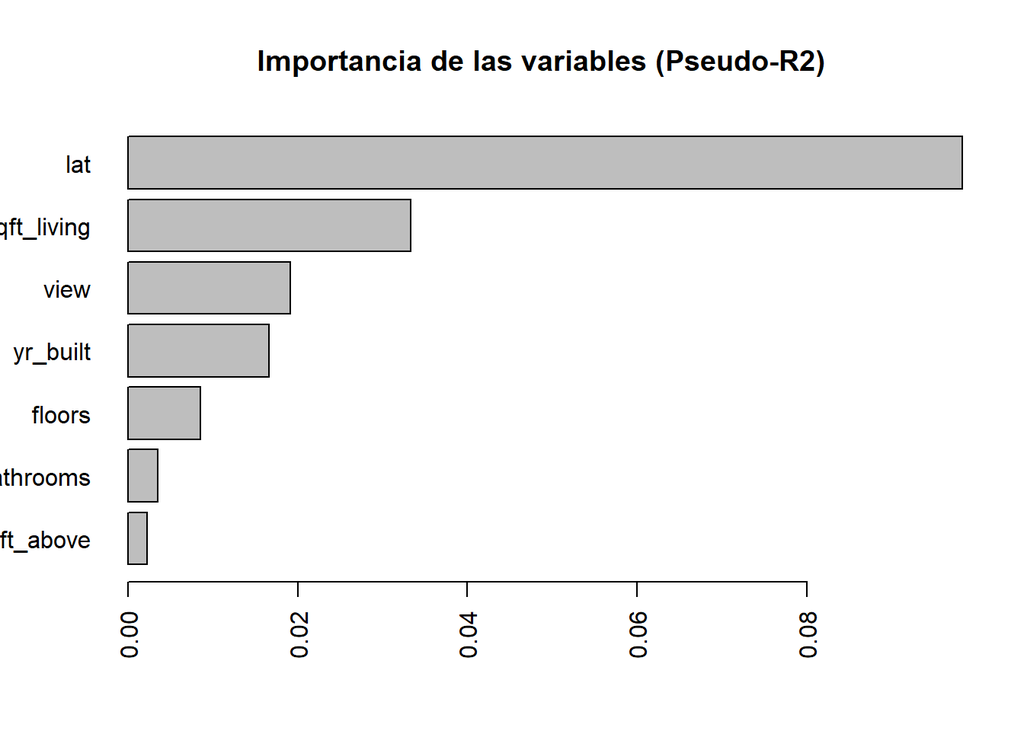

```r
# Nos fijamos en la importancia de las variables.
impVariablesLog(modeloC,"varObjBin")
```

## Selección de variables clásica

En primer lugar es conveniente seleccionar los mejores modelos con selección de variable bajo el esquema Training/Test.

### Solo efectos principales

Dado el conjunto con todas las variables sin transformaciones ni interacciones, trataremos de seleccionar las varibales más influyentes por un proceso de selección de variable bajo distintos criterios.

```r
# Seleccion de variables "clasica"
null<-glm(varObjBin~1, data=data_train, family = binomial) #Modelo minimo
full<-glm(varObjBin~., data=data_train[,c(1:16,29)], family = binomial) #Modelo maximo, le quitamos las transformaciones

modeloStepAIC<-step(null, scope=list(lower=null, upper=full), trace=0, direction="both")
summary(modeloStepAIC)
```

```
##
## Call:
## glm(formula = varObjBin ~ sqft_living + lat + view + floors +
##     yr_built + bedrooms + bathrooms + year + sqft_above + basement +
##     waterfront + sqft_lot + condition, family = binomial, data = data_train)
##
## Deviance Residuals:
##     Min       1Q   Median       3Q      Max
## -3.3726  -0.5742  -0.1836   0.5227   3.5507
##
## Coefficients:
##                Estimate Std. Error z value Pr(>|z|)
## (Intercept)  -3.676e+02  2.076e+01 -17.706  < 2e-16 ***
## sqft_living   1.436e-03  2.322e-04   6.185 6.23e-10 ***
## lat           8.453e+00  4.214e-01  20.060  < 2e-16 ***
## view1         1.529e+00  1.850e-01   8.269  < 2e-16 ***
## floors1.5     5.969e-01  1.778e-01   3.358 0.000786 ***
## floors2       2.740e-01  1.549e-01   1.769 0.076966 .
## floors2+      1.432e+00  2.596e-01   5.516 3.47e-08 ***
## yr_built     -2.055e-02  2.459e-03  -8.358  < 2e-16 ***
## bedrooms2    -2.047e-02  6.589e-01  -0.031 0.975211
## bedrooms3    -5.773e-01  6.548e-01  -0.882 0.377969
## bedrooms4    -8.766e-01  6.602e-01  -1.328 0.184268
## bedrooms5+   -1.236e+00  6.779e-01  -1.823 0.068357 .
## bathrooms1    1.002e-01  3.245e-01   0.309 0.757507
## bathrooms1.5 -2.856e-02  3.422e-01  -0.083 0.933494
## bathrooms2    5.344e-01  2.977e-01   1.795 0.072659 .
## bathrooms2.5  7.472e-01  2.960e-01   2.525 0.011580 *
## bathrooms3+   7.374e-01  3.154e-01   2.338 0.019387 *
## year2015      3.696e-01  9.756e-02   3.789 0.000151 ***
## sqft_above    1.395e-03  2.605e-04   5.356 8.51e-08 ***
## basement1     7.175e-01  1.857e-01   3.863 0.000112 ***
## waterfront1   1.732e+00  7.175e-01   2.414 0.015784 *
## sqft_lot     -1.627e-05  9.077e-06  -1.792 0.073074 .
## conditionB   -4.165e-01  1.819e-01  -2.290 0.022033 *
## conditionC   -2.357e-01  1.844e-01  -1.278 0.201102
## conditionD    1.290e-01  1.218e+00   0.106 0.915596
## ---
## Signif. codes:  0 '***' 0.001 '**' 0.01 '*' 0.05 '.' 0.1 ' ' 1
##
## (Dispersion parameter for binomial family taken to be 1)
##
##     Null deviance: 5451.0  on 4000  degrees of freedom
## Residual deviance: 3041.9  on 3976  degrees of freedom
## AIC: 3091.9
##
## Number of Fisher Scoring iterations: 6
```

```r
pseudoR2(modeloStepAIC,data_test,"varObjBin")
```

```
## [1] 0.4779745
```

```r
modeloBackAIC<-step(full, scope=list(lower=null, upper=full), trace=0, direction="backward")
summary(modeloBackAIC)
```

```
##
## Call:
## glm(formula = varObjBin ~ year + bedrooms + bathrooms + sqft_living +
##     sqft_lot + floors + waterfront + view + condition + sqft_above +
##     basement + yr_built + lat, family = binomial, data = data_train[,
##     c(1:16, 29)])
##
## Deviance Residuals:
##     Min       1Q   Median       3Q      Max
## -3.3726  -0.5742  -0.1836   0.5227   3.5507
##
## Coefficients:
##                Estimate Std. Error z value Pr(>|z|)
## (Intercept)  -3.676e+02  2.076e+01 -17.706  < 2e-16 ***
## year2015      3.696e-01  9.756e-02   3.789 0.000151 ***
## bedrooms2    -2.047e-02  6.589e-01  -0.031 0.975211
## bedrooms3    -5.773e-01  6.548e-01  -0.882 0.377969
## bedrooms4    -8.766e-01  6.602e-01  -1.328 0.184268
## bedrooms5+   -1.236e+00  6.779e-01  -1.823 0.068357 .
## bathrooms1    1.002e-01  3.245e-01   0.309 0.757507
## bathrooms1.5 -2.856e-02  3.422e-01  -0.083 0.933494
## bathrooms2    5.344e-01  2.977e-01   1.795 0.072659 .
## bathrooms2.5  7.472e-01  2.960e-01   2.525 0.011580 *
## bathrooms3+   7.374e-01  3.154e-01   2.338 0.019387 *
## sqft_living   1.436e-03  2.322e-04   6.185 6.23e-10 ***
## sqft_lot     -1.627e-05  9.077e-06  -1.792 0.073074 .
## floors1.5     5.969e-01  1.778e-01   3.358 0.000786 ***
## floors2       2.740e-01  1.549e-01   1.769 0.076966 .
## floors2+      1.432e+00  2.596e-01   5.516 3.47e-08 ***
## waterfront1   1.732e+00  7.175e-01   2.414 0.015784 *
## view1         1.529e+00  1.850e-01   8.269  < 2e-16 ***
## conditionB   -4.165e-01  1.819e-01  -2.290 0.022033 *
## conditionC   -2.357e-01  1.844e-01  -1.278 0.201102
## conditionD    1.290e-01  1.218e+00   0.106 0.915596
## sqft_above    1.395e-03  2.605e-04   5.356 8.51e-08 ***
## basement1     7.175e-01  1.857e-01   3.863 0.000112 ***
## yr_built     -2.055e-02  2.459e-03  -8.358  < 2e-16 ***
## lat           8.453e+00  4.214e-01  20.060  < 2e-16 ***
## ---
## Signif. codes:  0 '***' 0.001 '**' 0.01 '*' 0.05 '.' 0.1 ' ' 1
##
## (Dispersion parameter for binomial family taken to be 1)
##
##     Null deviance: 5451.0  on 4000  degrees of freedom
## Residual deviance: 3041.9  on 3976  degrees of freedom
## AIC: 3091.9
##
## Number of Fisher Scoring iterations: 6
```

```r
pseudoR2(modeloBackAIC,data_test,"varObjBin") #mismo modelo
```

```
## [1] 0.4779745
```

```r
modeloStepBIC<-step(null, scope=list(lower=null, upper=full), trace=0, direction="both",k=log(nrow(data_train)))
summary(modeloStepBIC)
```

```
##
## Call:
## glm(formula = varObjBin ~ sqft_living + lat + view + yr_built +
##     floors + year + sqft_above + basement, family = binomial,
##     data = data_train)
##
## Deviance Residuals:
##     Min       1Q   Median       3Q      Max
## -3.4069  -0.5924  -0.1980   0.5409   3.5959
##
## Coefficients:
##               Estimate Std. Error z value Pr(>|z|)
## (Intercept) -3.615e+02  2.010e+01 -17.986  < 2e-16 ***
## sqft_living  1.291e-03  2.100e-04   6.150 7.75e-10 ***
## lat          8.280e+00  4.104e-01  20.174  < 2e-16 ***
## view1        1.701e+00  1.777e-01   9.573  < 2e-16 ***
## yr_built    -1.958e-02  2.214e-03  -8.846  < 2e-16 ***
## floors1.5    4.789e-01  1.674e-01   2.861 0.004227 **
## floors2      3.928e-01  1.431e-01   2.745 0.006046 **
## floors2+     1.636e+00  2.437e-01   6.714 1.89e-11 ***
## year2015     3.293e-01  9.612e-02   3.426 0.000612 ***
## sqft_above   1.353e-03  2.522e-04   5.364 8.13e-08 ***
## basement1    7.871e-01  1.808e-01   4.352 1.35e-05 ***
## ---
## Signif. codes:  0 '***' 0.001 '**' 0.01 '*' 0.05 '.' 0.1 ' ' 1
##
## (Dispersion parameter for binomial family taken to be 1)
##
##     Null deviance: 5451.0  on 4000  degrees of freedom
## Residual deviance: 3106.4  on 3990  degrees of freedom
## AIC: 3128.4
##
## Number of Fisher Scoring iterations: 6
```

```r
pseudoR2(modeloStepBIC,data_test,"varObjBin")
```

```
## [1] 0.4725984
```

```r
modeloBackBIC<-step(full, scope=list(lower=null, upper=full), trace=0, direction="backward",k=log(nrow(data_train)))
summary(modeloBackBIC)
```

```
##
## Call:
## glm(formula = varObjBin ~ year + sqft_living + floors + view +
##     sqft_above + basement + yr_built + lat, family = binomial,
##     data = data_train[, c(1:16, 29)])
##
## Deviance Residuals:
##     Min       1Q   Median       3Q      Max
## -3.4069  -0.5924  -0.1980   0.5409   3.5959
##
## Coefficients:
##               Estimate Std. Error z value Pr(>|z|)
## (Intercept) -3.615e+02  2.010e+01 -17.986  < 2e-16 ***
## year2015     3.293e-01  9.612e-02   3.426 0.000612 ***
## sqft_living  1.291e-03  2.100e-04   6.150 7.75e-10 ***
## floors1.5    4.789e-01  1.674e-01   2.861 0.004227 **
## floors2      3.928e-01  1.431e-01   2.745 0.006046 **
## floors2+     1.636e+00  2.437e-01   6.714 1.89e-11 ***
## view1        1.701e+00  1.777e-01   9.573  < 2e-16 ***
## sqft_above   1.353e-03  2.522e-04   5.364 8.13e-08 ***
## basement1    7.871e-01  1.808e-01   4.352 1.35e-05 ***
## yr_built    -1.958e-02  2.214e-03  -8.846  < 2e-16 ***
## lat          8.280e+00  4.104e-01  20.174  < 2e-16 ***
## ---
## Signif. codes:  0 '***' 0.001 '**' 0.01 '*' 0.05 '.' 0.1 ' ' 1
##
## (Dispersion parameter for binomial family taken to be 1)
##
##     Null deviance: 5451.0  on 4000  degrees of freedom
## Residual deviance: 3106.4  on 3990  degrees of freedom
## AIC: 3128.4
##
## Number of Fisher Scoring iterations: 6
```

```r
pseudoR2(modeloBackBIC,data_test,"varObjBin")
```

```
## [1] 0.4725984
```

```r
modeloStepAIC$rank
```

```
## [1] 25
```

```r
modeloStepAIC$formula
```

```
## varObjBin ~ sqft_living + lat + view + floors + yr_built + bedrooms +
##     bathrooms + year + sqft_above + basement + waterfront + sqft_lot +
##     condition
```

```r
modeloStepBIC$rank
```

```
## [1] 11
```

```r
modeloStepBIC$formula
```

```
## varObjBin ~ sqft_living + lat + view + yr_built + floors + year +
##     sqft_above + basement
```

```r
modeloBackBIC$rank
```

```
## [1] 11
```

```r
modeloBackBIC$formula  ## Con el criterio BIC llegamos al mismo modelo con backward y stepwise
```

```
## varObjBin ~ year + sqft_living + floors + view + sqft_above +
##     basement + yr_built + lat
```

Tanto por AIC como por BIC, llegamos al mismo modelo por backward y stepwise. En cuanto a la comparaición entre ambos. AIC tiene doble de parámetros y un pseudo R2 superior en 5 milésimas…Parece que no justifica el aumento de parámetros…

### Efectos principales e interacciones

```r
#Genero interacciones
formInt<-formulaInteracciones(datos[,c(1:16,29)],17)#en el subconjunto de las vbles. originales, la objetivo está en la columna 17
fullInt<-glm(formInt, data=data_train, family = binomial)

# El modelo full es una locura y no tiene sentido..como es de esperar.
#summary(fullInt)
pseudoR2(fullInt,data_test,"varObjBin")
```

```
## [1] 0.230955
```

```r
# Empezamos con la seleción de variables
#modeloStepAIC_int<-step(null, scope=list(lower=null, upper=fullInt), trace=0,direction="both")
#summary(modeloStepAIC_int) # Demasiados efectos...y tarda un montón
#pseudoR2(modeloStepAIC_int,data_test,"varObjBin")
```

**El proceso es costoso a nivel computacional y tal vez podemos minimizar ese trabajo, yo quitaria bathrooms y bedrooms y tal vez floors para construir interacciones. Estas son las variabels con muchas categorías cuyas intesecciones son numerosas**

```r
#Genero interacciones sin algunas variabes categóricas
formInt<-formulaInteracciones(datos[,c(1,2,5:16,29)],15)
fullInt<-glm(formInt, data=data_train, family = binomial)

# Vuelvo a poner las variables bed y bath en el modelo
fullInt<-update(fullInt, .~.+bathrooms+bedrooms)

# Empezamos con la seleción de variables
modeloStepAIC_int<-step(null, scope=list(lower=null, upper=fullInt), trace=0, direction="both")
summary(modeloStepAIC_int)
```

```
##
## Call:
## glm(formula = varObjBin ~ sqft_living + lat + view + floors +
##     yr_built + bedrooms + bathrooms + sqft_above + basement +
##     year + waterfront + sqft_lot + lat:floors + sqft_above:basement +
##     floors:yr_built + floors:basement + sqft_living:year + lat:view +
##     sqft_living:floors + floors:sqft_lot + basement:sqft_lot,
##     family = binomial, data = data_train)
##
## Deviance Residuals:
##     Min       1Q   Median       3Q      Max
## -3.1339  -0.5530  -0.1758   0.4862   3.5656
##
## Coefficients:
##                         Estimate Std. Error z value Pr(>|z|)
## (Intercept)           -2.387e+02  2.796e+01  -8.539  < 2e-16 ***
## sqft_living            1.930e-03  2.552e-04   7.563 3.93e-14 ***
## lat                    5.949e+00  5.663e-01  10.504  < 2e-16 ***
## view1                 -1.444e+02  8.216e+01  -1.758 0.078762 .
## floors1.5             -2.283e+02  7.623e+01  -2.995 0.002743 **
## floors2               -2.770e+02  4.679e+01  -5.919 3.23e-09 ***
## floors2+              -3.381e+01  1.855e+02  -0.182 0.855355
## yr_built              -2.594e-02  3.684e-03  -7.043 1.88e-12 ***
## bedrooms2             -2.157e-01  6.573e-01  -0.328 0.742807
## bedrooms3             -7.654e-01  6.545e-01  -1.169 0.242223
## bedrooms4             -1.046e+00  6.609e-01  -1.583 0.113367
## bedrooms5+            -1.468e+00  6.794e-01  -2.161 0.030724 *
## bathrooms1             5.227e-02  3.336e-01   0.157 0.875479
## bathrooms1.5           2.526e-02  3.497e-01   0.072 0.942419
## bathrooms2             5.250e-01  3.038e-01   1.728 0.084025 .
## bathrooms2.5           8.395e-01  3.041e-01   2.761 0.005770 **
## bathrooms3+            8.452e-01  3.221e-01   2.624 0.008687 **
## sqft_above             1.693e-03  3.038e-04   5.575 2.47e-08 ***
## basement1              1.481e+00  3.704e-01   3.997 6.42e-05 ***
## year2015               1.193e+00  3.332e-01   3.581 0.000342 ***
## waterfront1            1.949e+00  7.892e-01   2.469 0.013535 *
## sqft_lot              -5.911e-05  2.140e-05  -2.762 0.005737 **
## lat:floors1.5          4.480e+00  1.566e+00   2.860 0.004232 **
## lat:floors2            5.596e+00  9.452e-01   5.921 3.21e-09 ***
## lat:floors2+          -9.768e-01  3.707e+00  -0.263 0.792176
```

[output cut: 11 more lines]

```
## sqft_living:floors2+   1.447e-03  9.609e-04   1.506 0.132061
## floors1.5:sqft_lot    -3.376e-05  4.021e-05  -0.840 0.401107
## floors2:sqft_lot       7.246e-05  2.390e-05   3.032 0.002431 **
## floors2+:sqft_lot     -2.134e-04  1.226e-04  -1.741 0.081715 .
## basement1:sqft_lot     3.581e-05  2.286e-05   1.566 0.117302
## ---
## Signif. codes:  0 '***' 0.001 '**' 0.01 '*' 0.05 '.' 0.1 ' ' 1
##
## (Dispersion parameter for binomial family taken to be 1)
##
##     Null deviance: 5451.0  on 4000  degrees of freedom
## Residual deviance: 2937.7  on 3960  degrees of freedom
## AIC: 3019.7
##
## Number of Fisher Scoring iterations: 6
```

```r
pseudoR2(modeloStepAIC_int,data_test,"varObjBin")
```

```
## [1] 0.4815148
```

```r
modeloStepBIC_int<-step(null, scope=list(lower=null, upper=fullInt), trace=0, direction="both",k=log(nrow(data_train)))
summary(modeloStepBIC_int)
```

```
##
## Call:
## glm(formula = varObjBin ~ sqft_living + lat + view + yr_built +
##     floors + sqft_above + basement + year + lat:floors + sqft_above:basement,
##     family = binomial, data = data_train)
##
## Deviance Residuals:
##     Min       1Q   Median       3Q      Max
## -3.2415  -0.5686  -0.1966   0.5221   3.4564
##
## Coefficients:
##                        Estimate Std. Error z value Pr(>|z|)
## (Intercept)          -2.572e+02  2.560e+01 -10.048  < 2e-16 ***
## sqft_living           1.309e-03  2.058e-04   6.360 2.01e-10 ***
## lat                   6.060e+00  5.257e-01  11.526  < 2e-16 ***
## view1                 1.659e+00  1.755e-01   9.455  < 2e-16 ***
## yr_built             -1.911e-02  2.244e-03  -8.515  < 2e-16 ***
## floors1.5            -2.618e+02  6.954e+01  -3.765 0.000166 ***
## floors2              -2.438e+02  4.060e+01  -6.005 1.91e-09 ***
## floors2+              8.456e+01  1.268e+02   0.667 0.505006
## sqft_above            1.594e-03  2.540e-04   6.275 3.49e-10 ***
## basement1             1.732e+00  3.312e-01   5.230 1.69e-07 ***
## year2015              3.343e-01  9.698e-02   3.447 0.000567 ***
## lat:floors1.5         5.511e+00  1.461e+00   3.773 0.000162 ***
## lat:floors2           5.130e+00  8.530e-01   6.014 1.81e-09 ***
## lat:floors2+         -1.737e+00  2.662e+00  -0.653 0.513963
## sqft_above:basement1 -6.212e-04  1.917e-04  -3.240 0.001195 **
## ---
## Signif. codes:  0 '***' 0.001 '**' 0.01 '*' 0.05 '.' 0.1 ' ' 1
##
## (Dispersion parameter for binomial family taken to be 1)
##
##     Null deviance: 5451.0  on 4000  degrees of freedom
## Residual deviance: 3052.6  on 3986  degrees of freedom
## AIC: 3082.6
##
## Number of Fisher Scoring iterations: 6
```

```r
pseudoR2(modeloStepBIC_int,data_test,"varObjBin")# ALgo menos de pseudo R2
```

```
## [1] 0.4795665
```

```r
modeloStepAIC_int$rank #muchos más parámetros
```

```
## [1] 41
```

```r
formula(modeloStepAIC_int)
```

```
## varObjBin ~ sqft_living + lat + view + floors + yr_built + bedrooms +
##     bathrooms + sqft_above + basement + year + waterfront + sqft_lot +
##     lat:floors + sqft_above:basement + floors:yr_built + floors:basement +
##     sqft_living:year + lat:view + sqft_living:floors + floors:sqft_lot +
##     basement:sqft_lot
```

```r
modeloStepBIC_int$rank
```

```
## [1] 15
```

```r
formula(modeloStepBIC_int) # Me quedaría con este por parsimonia
```

```
## varObjBin ~ sqft_living + lat + view + yr_built + floors + sqft_above +
##     basement + year + lat:floors + sqft_above:basement
```

De nuevo, el AIC tiende a decidirse por modelos más complejos en número de parámetros y las diferencias en pseudo R2 no son relevantes. Parece más adecuado aplicar el principio de parsimonia y quedarse con el BIC

### Efectos principales y transformaciones de variables numéricas

En este punto se prueban modelos de selección de variables considerando variable originales y sus transformaciones, sin interacciones entre ellas. En este caso habrá que tener precaución en los modelos generados ya que es posible que aparezcan variables originales y sus transformaciones en el modelo. Esto es indetectable para la función automática *step()* y puede causar muchos problemas en la estimación de los parámetros debido a predictores con alta relación.

Commo siempre, la inspección manual nos puede salvar de cometer errores importantes!

```r
# Pruebo con todas las transformaciones
fullT<-glm(varObjBin~., data=data_train, family = binomial)

modeloStepAIC_trans<-step(null, scope=list(lower=null, upper=fullT), trace=0, direction="both")
summary(modeloStepAIC_trans)
```

```
##
## Call:
## glm(formula = varObjBin ~ sqft_living + lat + sqrxlat + view +
##     floors + sqrtxyr_built + sqft_above + bedrooms + raiz4long +
##     year + bathrooms + waterfront + basement + condition + prop_missings +
##     xaleatorio + aleatorio2, family = binomial, data = data_train)
##
## Deviance Residuals:
##     Min       1Q   Median       3Q      Max
## -3.6899  -0.5142  -0.0539   0.4235   5.0888
##
## Coefficients:
##                 Estimate Std. Error z value Pr(>|z|)
## (Intercept)   -3.213e+03  1.899e+02 -16.923  < 2e-16 ***
## sqft_living    1.435e-03  2.454e-04   5.849 4.94e-09 ***
## lat            6.775e+01  4.008e+00  16.903  < 2e-16 ***
## sqrxlat       -1.346e+00  8.632e-02 -15.591  < 2e-16 ***
## view1          1.402e+00  2.073e-01   6.761 1.37e-11 ***
## floors1.5      4.045e-01  1.888e-01   2.142  0.03217 *
## floors2       -3.010e-01  1.626e-01  -1.851  0.06417 .
## floors2+       7.115e-01  2.779e-01   2.561  0.01045 *
## sqrtxyr_built -8.694e-01  1.837e-01  -4.732 2.22e-06 ***
## sqft_above     1.977e-03  2.841e-04   6.961 3.37e-12 ***
## bedrooms2     -1.940e-01  6.599e-01  -0.294  0.76878
## bedrooms3     -7.596e-01  6.589e-01  -1.153  0.24903
## bedrooms4     -1.089e+00  6.675e-01  -1.632  0.10274
## bedrooms5+    -1.453e+00  6.892e-01  -2.109  0.03495 *
## raiz4long     -1.699e+00  4.351e-01  -3.904 9.46e-05 ***
## year2015       4.288e-01  1.051e-01   4.079 4.52e-05 ***
## bathrooms1     2.307e-01  3.427e-01   0.673  0.50071
## bathrooms1.5   7.807e-02  3.624e-01   0.215  0.82944
## bathrooms2     6.051e-01  3.165e-01   1.912  0.05590 .
## bathrooms2.5   7.747e-01  3.156e-01   2.455  0.01411 *
## bathrooms3+    7.137e-01  3.380e-01   2.111  0.03474 *
## waterfront1    2.597e+00  8.675e-01   2.994  0.00276 **
## basement1      6.444e-01  1.941e-01   3.320  0.00090 ***
## conditionB    -5.243e-01  1.887e-01  -2.779  0.00546 **
## conditionC    -2.722e-01  1.939e-01  -1.404  0.16027
## conditionD    -5.336e-01  1.231e+00  -0.433  0.66477
## prop_missings  4.705e+00  2.079e+00   2.264  0.02359 *
## xaleatorio    -9.252e-02  4.917e-02  -1.882  0.05987 .
## aleatorio2     2.586e-01  1.687e-01   1.533  0.12538
## ---
## Signif. codes:  0 '***' 0.001 '**' 0.01 '*' 0.05 '.' 0.1 ' ' 1
##
## (Dispersion parameter for binomial family taken to be 1)
##
##     Null deviance: 5451.0  on 4000  degrees of freedom
## Residual deviance: 2667.3  on 3972  degrees of freedom
## AIC: 2725.3
##
## Number of Fisher Scoring iterations: 7
```

```r
pseudoR2(modeloStepAIC_trans,data_test,"varObjBin")
```

```
## [1] 0.5473386
```

```r
modeloStepBIC_trans<-step(null, scope=list(lower=null, upper=fullT), trace=0, direction="both",k=log(nrow(data_train)))
summary(modeloStepBIC_trans)
```

```
##
## Call:
## glm(formula = varObjBin ~ sqft_living + lat + sqrxlat + view +
##     sqrtxyr_built + sqft_above + raiz4long + year + waterfront +
##     basement, family = binomial, data = data_train)
##
## Deviance Residuals:
##     Min       1Q   Median       3Q      Max
## -3.6572  -0.5449  -0.0569   0.4324   5.3200
##
## Coefficients:
##                 Estimate Std. Error z value Pr(>|z|)
## (Intercept)   -3.200e+03  1.828e+02 -17.504  < 2e-16 ***
## sqft_living    1.343e-03  2.118e-04   6.342 2.27e-10 ***
## lat            6.747e+01  3.859e+00  17.485  < 2e-16 ***
## sqrxlat       -1.339e+00  8.309e-02 -16.112  < 2e-16 ***
## view1          1.463e+00  2.030e-01   7.209 5.64e-13 ***
## sqrtxyr_built -8.519e-01  1.396e-01  -6.103 1.04e-09 ***
## sqft_above     1.758e-03  2.449e-04   7.178 7.09e-13 ***
## raiz4long     -1.943e+00  3.941e-01  -4.931 8.19e-07 ***
## year2015       3.889e-01  1.027e-01   3.788 0.000152 ***
## waterfront1    2.661e+00  8.689e-01   3.063 0.002193 **
## basement1      5.763e-01  1.844e-01   3.126 0.001774 **
## ---
## Signif. codes:  0 '***' 0.001 '**' 0.01 '*' 0.05 '.' 0.1 ' ' 1
##
## (Dispersion parameter for binomial family taken to be 1)
##
##     Null deviance: 5451.0  on 4000  degrees of freedom
## Residual deviance: 2748.6  on 3990  degrees of freedom
## AIC: 2770.6
##
## Number of Fisher Scoring iterations: 7
```

```r
pseudoR2(modeloStepBIC_trans,data_test,"varObjBin")
```

```
## [1] 0.5476869
```

```r
modeloStepAIC_trans$rank
```

```
## [1] 29
```

```r
modeloStepBIC_trans$rank
```

```
## [1] 11
```

```r
modeloStepBIC_trans$formula # Muchos menos parámetros. Cuidado con las transfomaciones y las variables originales juntas
```

```
## varObjBin ~ sqft_living + lat + sqrxlat + view + sqrtxyr_built +
##     sqft_above + raiz4long + year + waterfront + basement
```

En este caso se produce una mejora sustancial del pseudo R2 en ambos modelos, siendo el BIC superior en todo (menos parámetros y mayor pseudo R2). Es el claro candidato a modelo ganador.

**Problema**: Esta considerando lat y sqrxlat que son variables con alta correlación, ya que una es transformación de la otra. El modelo encuentra un patron de clasificación al considerar ambas variables ismultaneamente en el modelo. Esto no parece adecuado y puede dar problemas de estimación de los parámetros.

Cuando sucede esto, es importante detectarlo y actuar en consecuencia. En este caso, puede no tener sentido que aparezcan ambas variables juntas en el modelo pues nos está diciendo que un aumento el lat tiene un efecto positivo cuando sqrxlat se mantienen constante, pero si una crece la otra tb…con lo cual la interpretación se complicaría sobremanera…como justificar esto?

Miraremos los errores en la estimación de los parámetros

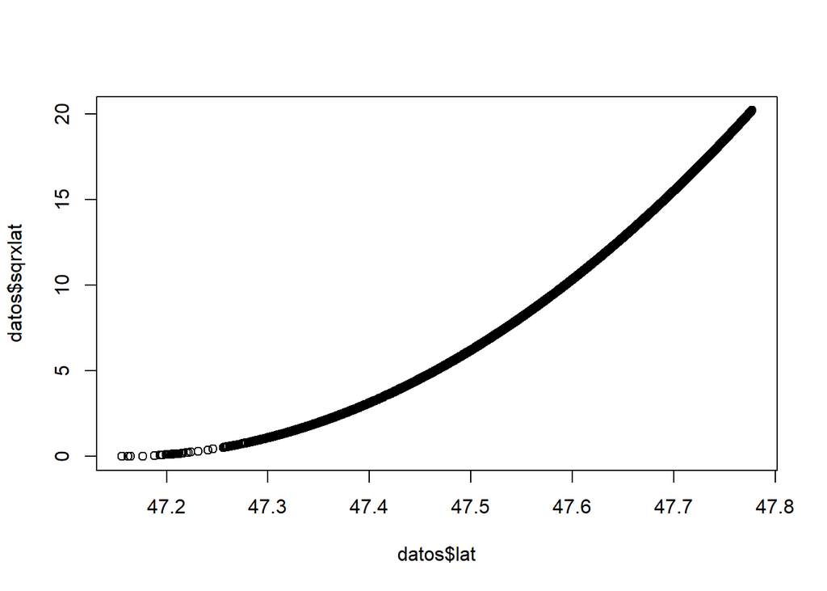

```r
plot(datos$lat,datos$sqrxlat)
```

```r
cor(datos$lat,datos$sqrxlat) # Correlación de 0.98!!
```

```
## [1] 0.9812708
```

En este caso, ya que la interpretación sería imposible (no se entiende el efecto de una a igualdad de valores de la otra), lo más adecuado sería eliminar una de ellas. Para ello, es buena idea ver el posible efecto de ambas sobre la respuesta y quedarnos con la que más potencial disciminatorio tenga.

```r
aggregate(lat ~varObjBin, data = datos, mean)
```

| varObjBin | lat |
| --- | --- |
| 0 | 47.51976 |
| 1 | 47.61786 |

```r
aggregate(sqrxlat ~varObjBin, data = datos, mean)
```

| varObjBin | sqrxlat |
| --- | --- |
| 0 | 8.160424 |
| 1 | 11.569174 |

Las medias de la segunda difieren en mayor medida en los subgrupos de 0 y 1 de la variable objetivo, por tanto, es mejor mantener la transformada.

```r
# Actualizar modelo eliminando lat
modeloStepBIC_trans_update<-update(modeloStepBIC_trans, .~.-lat)
summary(modeloStepBIC_trans_update)
```

```
##
## Call:
## glm(formula = varObjBin ~ sqft_living + sqrxlat + view + sqrtxyr_built +
##     sqft_above + raiz4long + year + waterfront + basement, family = binomial,
##     data = data_train)
##
## Deviance Residuals:
##     Min       1Q   Median       3Q      Max
## -3.2400  -0.6218  -0.2493   0.5951   3.1976
##
## Coefficients:
##                 Estimate Std. Error z value Pr(>|z|)
## (Intercept)   -4.8288213  0.4156046 -11.619  < 2e-16 ***
## sqft_living    0.0011222  0.0001982   5.663 1.49e-08 ***
## sqrxlat        0.1715585  0.0089964  19.070  < 2e-16 ***
## view1          1.5058266  0.1734929   8.679  < 2e-16 ***
## sqrtxyr_built -1.3013965  0.1333031  -9.763  < 2e-16 ***
## sqft_above     0.0014908  0.0002242   6.650 2.93e-11 ***
## raiz4long     -0.6352326  0.3535434  -1.797 0.072374 .
## year2015       0.3190674  0.0934146   3.416 0.000636 ***
## waterfront1    1.3355941  0.6720839   1.987 0.046895 *
## basement1      0.7643976  0.1759084   4.345 1.39e-05 ***
## ---
## Signif. codes:  0 '***' 0.001 '**' 0.01 '*' 0.05 '.' 0.1 ' ' 1
##
## (Dispersion parameter for binomial family taken to be 1)
##
##     Null deviance: 5451  on 4000  degrees of freedom
## Residual deviance: 3280  on 3991  degrees of freedom
## AIC: 3300
##
## Number of Fisher Scoring iterations: 5
```

```r
pseudoR2(modeloStepBIC_trans_update,data_test,"varObjBin")
```

```
## [1] 0.4398629
```

La capacidad predictiva del modelo se ve seriamene afectada…

### Todos los efectos principales, transfomaciones y todas sus interacciones

En este punto vamos más allá e intentamos captar patrones subyacentes no observados combinado todos los posibles efectos. Hay que tener en cuenta que el proceso puede ser largo ya que hay muchos efectos para la selección.

Recordemos quitar lat (columna 13) para no tener el problema anterior!

```r
#Trans e interacciones
formIntT<-formulaInteracciones(datos[,-c(3,4,13,14)],25)
fullIntT<-glm(formIntT, data=data_train, family = binomial)

# Vuelvo a poner las variables bed y bath en el modelo
fullIntT<-update(fullIntT, .~.+bathrooms+bedrooms)

modeloStepAIC_transInt<-step(null, scope=list(lower=null, upper=fullIntT), trace=0, direction="both")
summary(modeloStepAIC_transInt)
```

```
##
## Call:
## glm(formula = varObjBin ~ sqft_living + sqrxlat + sqrtxyr_built +
##     view + floors + bedrooms + bathrooms + year + sqft_above +
##     basement + sqrtxsqft_above + waterfront + sqrtxsqft_lot +
##     sqft_lot + condition + raiz4aleatorio2 + aleatorio + sqrxlat:floors +
##     sqrxlat:view + sqft_living:basement + sqrtxyr_built:floors +
##     floors:basement + floors:sqft_above + sqft_living:year +
##     floors:sqrtxsqft_lot + sqrxlat:waterfront + sqrxlat:condition +
##     basement:condition + sqrxlat:year + floors:raiz4aleatorio2 +
##     view:raiz4aleatorio2 + floors:year, family = binomial, data = data_train)
##
## Deviance Residuals:
##     Min       1Q   Median       3Q      Max
## -3.3071  -0.5663  -0.1838   0.5026   3.3655
##
## Coefficients:
##                             Estimate Std. Error z value Pr(>|z|)
## (Intercept)               -7.364e+00  1.255e+00  -5.868 4.42e-09 ***
## sqft_living                2.821e-03  3.444e-04   8.191 2.60e-16 ***
## sqrxlat                    1.169e-01  3.346e-02   3.494 0.000476 ***
## sqrtxyr_built             -1.731e+00  2.615e-01  -6.620 3.60e-11 ***
## view1                      1.612e+00  9.662e-01   1.668 0.095274 .
## floors1.5                 -2.746e+00  1.353e+00  -2.029 0.042419 *
## floors2                   -5.119e+00  1.060e+00  -4.828 1.38e-06 ***
## floors2+                  -3.912e+00  2.959e+00  -1.322 0.186089
## bedrooms2                 -7.355e-02  7.589e-01  -0.097 0.922787
## bedrooms3                 -8.373e-01  7.579e-01  -1.105 0.269282
## bedrooms4                 -1.109e+00  7.636e-01  -1.453 0.146288
## bedrooms5+                -1.442e+00  7.775e-01  -1.855 0.063581 .
## bathrooms1                 1.266e-01  3.388e-01   0.374 0.708713
## bathrooms1.5               7.205e-02  3.543e-01   0.203 0.838882
## bathrooms2                 5.038e-01  3.065e-01   1.644 0.100265
## bathrooms2.5               8.549e-01  3.059e-01   2.795 0.005196 **
## bathrooms3+                8.209e-01  3.226e-01   2.545 0.010936 *
## year2015                   4.263e-01  4.773e-01   0.893 0.371759
## sqft_above                -3.583e-03  9.080e-04  -3.946 7.95e-05 ***
## basement1                  2.937e+00  5.095e-01   5.764 8.20e-09 ***
## sqrtxsqft_above            8.402e+00  1.732e+00   4.851 1.23e-06 ***
## waterfront1               -1.561e+00  2.880e+00  -0.542 0.587699
```

[output cut: 35 more lines]

```
## floors2+:raiz4aleatorio2  -1.294e+00  1.119e+00  -1.156 0.247516
## view1:raiz4aleatorio2     -1.301e+00  8.106e-01  -1.605 0.108584
## floors1.5:year2015         7.885e-01  3.556e-01   2.218 0.026576 *
## floors2:year2015           4.027e-02  2.360e-01   0.171 0.864529
## floors2+:year2015          6.291e-01  5.195e-01   1.211 0.225837
## ---
## Signif. codes:  0 '***' 0.001 '**' 0.01 '*' 0.05 '.' 0.1 ' ' 1
##
## (Dispersion parameter for binomial family taken to be 1)
##
##     Null deviance: 5451.0  on 4000  degrees of freedom
## Residual deviance: 2968.8  on 3939  degrees of freedom
## AIC: 3092.8
##
## Number of Fisher Scoring iterations: 13
```

```r
pseudoR2(modeloStepAIC_transInt,data_test,"varObjBin")
```

```
## [1] 0.4625238
```

```r
modeloStepBIC_transInt<-step(null, scope=list(lower=null, upper=fullIntT), trace=0, direction="both",k=log(nrow(data_train)))
summary(modeloStepBIC_transInt)
```

```
##
## Call:
## glm(formula = varObjBin ~ sqft_living + sqrxlat + sqrtxyr_built +
##     view + floors + year + sqft_above + basement + sqrxlat:floors +
##     sqft_living:basement, family = binomial, data = data_train)
##
## Deviance Residuals:
##     Min       1Q   Median       3Q      Max
## -3.1660  -0.6032  -0.2336   0.5513   3.3048
##
## Coefficients:
##                         Estimate Std. Error z value Pr(>|z|)
## (Intercept)           -5.2411738  0.3174699 -16.509  < 2e-16 ***
## sqft_living            0.0018738  0.0002955   6.341 2.28e-10 ***
## sqrxlat                0.1157304  0.0115404  10.028  < 2e-16 ***
## sqrtxyr_built         -1.4954430  0.1567095  -9.543  < 2e-16 ***
## view1                  1.5936633  0.1686129   9.452  < 2e-16 ***
## floors1.5             -1.2708019  0.4134688  -3.074 0.002116 **
## floors2               -1.0197777  0.2463782  -4.139 3.49e-05 ***
## floors2+               2.9519402  1.0145533   2.910 0.003619 **
## year2015               0.3140758  0.0949704   3.307 0.000943 ***
## sqft_above             0.0008944  0.0002939   3.043 0.002340 **
## basement1              1.6565309  0.3253795   5.091 3.56e-07 ***
## sqrxlat:floors1.5      0.1569689  0.0344589   4.555 5.23e-06 ***
## sqrxlat:floors2        0.1281205  0.0196386   6.524 6.85e-11 ***
## sqrxlat:floors2+      -0.0905613  0.0734225  -1.233 0.217416
## sqft_living:basement1 -0.0005547  0.0001877  -2.955 0.003131 **
## ---
## Signif. codes:  0 '***' 0.001 '**' 0.01 '*' 0.05 '.' 0.1 ' ' 1
##
## (Dispersion parameter for binomial family taken to be 1)
##
##     Null deviance: 5451  on 4000  degrees of freedom
## Residual deviance: 3172  on 3986  degrees of freedom
## AIC: 3202
##
## Number of Fisher Scoring iterations: 6
```

```r
pseudoR2(modeloStepBIC_transInt,data_test,"varObjBin")#
```

```
## [1] 0.456816
```

```r
modeloStepAIC_transInt$rank
```

```
## [1] 62
```

```r
modeloStepBIC_transInt$rank
```

```
## [1] 15
```

```r
#Por el principio de parsimonia, es preferible el modeloStepBIC_transInt
```

**Repaso de mejores modelos**

```r
pseudoR2(modeloC,data_test,"varObjBin")
```

```
## [1] 0.4735186
```

```r
pseudoR2(modeloStepBIC,data_test,"varObjBin")
```

```
## [1] 0.4725984
```

```r
pseudoR2(modeloStepBIC_trans,data_test,"varObjBin") ## Modelo con colinealidad!
```

```
## [1] 0.5476869
```

```r
pseudoR2(modeloStepBIC_trans_update,data_test,"varObjBin")
```

```
## [1] 0.4398629
```

```r
pseudoR2(modeloStepBIC_transInt,data_test,"varObjBin")
```

```
## [1] 0.456816
```